# Main Study Analysis: The Compatibility Effect between Physical Stimulus Size and Left-Right Responses

Florian Pätzold 977687, Daniel Menzel 979379, Ramon Zacharias 977316, Shari Hiltner 979694

24/07/2020

This analysis script is largely based on the internet tutorial, which you can find here: [https://www.scribbr.com/statistics/anova-in-r/].

## 0. Setting up the required packages

```r
# package for convenience functions (e.g. ggplot2, dplyr, etc.)
library(tidyverse)

library(ggplot2)
library(ggpubr)
library(broom)

# package for AIC evaluation
library(AICcmodavg)

# package to visualize
library(bayesplot)

# global color scheme / non-optimized
project_colors = c("#E69F00", "#56B4E9", "#009E73", "#F0E442", "#0072B2", "#D55E00", "#CC79A7", "#000000")

# setting theme colors globally
scale_colour_discrete <- function(...) {
  scale_colour_manual(..., values = project_colors)
}
scale_fill_discrete <- function(...) {
   scale_fill_manual(..., values = project_colors)
}

# define scale function to avoid matrix object in tibble
my_scale <- function(x) c(scale(x))
```

# 1. Load in the data.

```r
# Load in the data from the pilot study
comp_raw <- read_csv("/Users/florian/Documents/Studium/Semester_4/Experimental Psychology Lab/Final_Project/data/compatibility_raw.csv")

# Let's have a look at the raw data set (the "key1" values should not be logical "FALSE" but character data type: "f")
comp_raw
```

```
## # A tibble: 4,800 x 24
##    submission_id Mapping    RT   age comments correctness education endTime
##            <dbl> <chr>   <dbl> <dbl> <chr>    <chr>       <chr>       <dbl>
##  1          1984 incomp…  3240    66 <NA>     correct     Graduate… 1.60e12
##  2          1984 incomp…   675    66 <NA>     correct     Graduate… 1.60e12
##  3          1984 incomp…   957    66 <NA>     correct     Graduate… 1.60e12
##  4          1984 incomp…   390    66 <NA>     correct     Graduate… 1.60e12
##  5          1984 incomp…   511    66 <NA>     correct     Graduate… 1.60e12
##  6          1984 incomp…   691    66 <NA>     correct     Graduate… 1.60e12
##  7          1984 incomp…   604    66 <NA>     correct     Graduate… 1.60e12
##  8          1984 incomp…   595    66 <NA>     correct     Graduate… 1.60e12
##  9          1984 incomp…   456    66 <NA>     correct     Graduate… 1.60e12
## 10          1984 incomp…   675    66 <NA>     correct     Graduate… 1.60e12
## # … with 4,790 more rows, and 16 more variables: expected <chr>,
## #   experiment_id <dbl>, f <chr>, gender <chr>, handedness <chr>, j <chr>,
## #   key1 <lgl>, key2 <chr>, key_pressed <chr>, languages <chr>, picture <chr>,
## #   startDate <chr>, startTime <dbl>, timeSpent <dbl>, trial_number <dbl>,
## #   trial_type <chr>
```

# 2. Processing and cleaning the data

Time to clean our data! Find the justification of the cleaning process in the preregistration of our study.

```r
# We exclude columns, that are not required for the analysis
comp_data <- comp_raw %>%
  dplyr::select(submission_id,
         trial_type,
         key_pressed,
         Mapping,
         correctness,
         RT,
         handedness, # discard data from left-handers because of H2
         timeSpent # discard data from participants, that finished experiment faster than 5min
         ) %>%
  rename("response" = "key_pressed") %>%
  rename("mapping" = "Mapping") %>%
  rename("time_spent" = "timeSpent") %>%
  filter(handedness == "right" & RT > 100 & RT < 1500 & time_spent > 5 & trial_type == "main" & correctness == "correct") # data exclusion (see preregistration)

# Change key name to response location
for (i in 1:length(comp_data$response)) {
  if(comp_data$response[i] == "j") {
    comp_data$response[i] <- "right"
  } else {
    comp_data$response[i] <- "left"
  }
}

comp_data
```

```
## # A tibble: 3,357 x 8
##    submission_id trial_type response mapping correctness    RT handedness
##            <dbl> <chr>      <chr>    <chr>   <chr>       <dbl> <chr>
##  1          1984 main       left     incomp… correct       689 right
##  2          1984 main       left     incomp… correct       764 right
##  3          1984 main       right    incomp… correct       641 right
##  4          1984 main       left     incomp… correct       628 right
##  5          1984 main       right    incomp… correct       441 right
##  6          1984 main       left     incomp… correct       553 right
##  7          1984 main       left     incomp… correct       835 right
##  8          1984 main       right    incomp… correct       493 right
##  9          1984 main       right    incomp… correct       609 right
## 10          1984 main       left     incomp… correct       402 right
## # … with 3,347 more rows, and 1 more variable: time_spent <dbl>
```

# 3. Visualizing the data.

To get a good idea of what our data looks like we now plot the mean reaction times for the different mapping conditions (compatible and incompatible) grouped by response locations (left and right).

```r
# Define a function for calculating the standard error
se <- function(x) sd(x) / sqrt(length(x))

# aggregate mean reaction times per subject and mapping condition
comp_data_agg <- comp_data %>%
  group_by(response, mapping) %>%
  summarise(mean_RT = mean(RT), se_RT = se(RT))

# the aggregated data frame
comp_data_agg
```

```
## # A tibble: 4 x 4
## # Groups:   response [2]
##   response mapping      mean_RT se_RT
##   <chr>    <chr>          <dbl> <dbl>
## 1 left     compatible      529.  6.71
## 2 left     incompatible    509.  5.83
## 3 right    compatible      527.  6.88
## 4 right    incompatible    520.  5.40
```

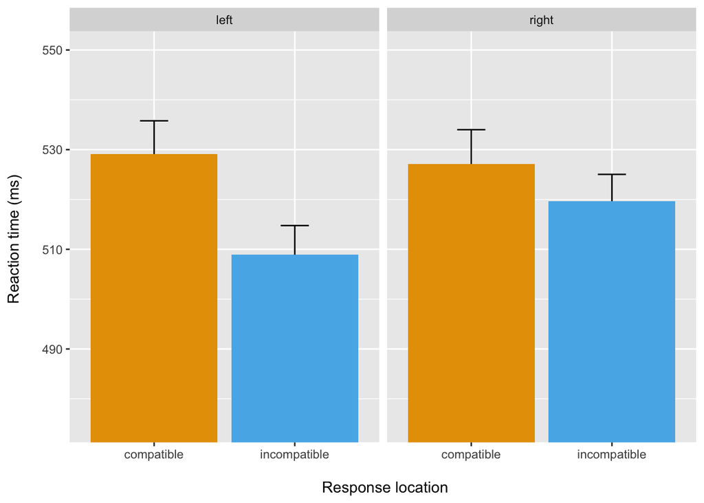

```r
comp_data_agg %>% ggplot(aes(x = mapping, y = mean_RT, fill = mapping)) +
  geom_errorbar(aes(ymin = mean_RT - se_RT, ymax = mean_RT + se_RT), width = 0.2) +
  geom_col() +
  ylab("Reaction time (ms) \n") +
  xlab("\n Response location") +
  facet_grid(~response) +
  coord_cartesian(ylim = c(475,550)) +
  legend_none()
```